# Presentation Figures: Hawksbill Sea Turtle Microbiome

Edgardo L. Rosado Ramos

2025-10-17

# 1. Setup: Defining the Wong Color Palette

This chunk defines our color palette, which will be used for all subsequent plots to ensure consistency and readability.

```r
# The colorblind-safe palette developed by Bang Wong
wong_palette <- c(
  Buccal = "#0072B2",   # Blue
  Cloaca = "#D55E00",   # Vermillion/Red-Orange
  Control = "#009E73"    # Green
)

# A separate mapping for the health status plots
health_status_colors <- c(
  "Healthy Baseline" = "gray70",
  "Helicobacter Cluster" = "#CC79A7", # Reddish Purple
  "Chlamydophila Case" = "#E69F00"  # Orange
)
```

# 2. Data Import and Cleaning

This chunk imports all data, cleans the metadata formatting, and creates our final, clean `physeq_final` object. This is the foundation for all plots.

```r
# --- OTU Table ---
otu_raw <- read.table("final.opti_mcc.0.03.subsample.shared", header = TRUE, sep = "\t")
otu_mat <- t(otu_raw[, -(1:3)]); colnames(otu_mat) <- otu_raw$Group
otu_tab <- otu_table(otu_mat, taxa_are_rows = TRUE)

# --- Taxonomy Table ---
tax_raw <- read.table("final.opti_mcc.0.03.cons.taxonomy", sep = "\t", header = TRUE, quote = "")
taxonomy_strings <- tax_raw$Taxonomy; names(taxonomy_strings) <- tax_raw$OTU
taxonomy_clean <- lapply(strsplit(taxonomy_strings, ";"), function(x) gsub("\\(.*?\\)|\\\"", "", x))
taxonomy_mat <- do.call(rbind, lapply(taxonomy_clean, `length<-`, 7))
colnames(taxonomy_mat) <- c("Kingdom", "Phylum", "Class", "Order", "Family", "Genus", "Species")
rownames(taxonomy_mat) <- names(taxonomy_strings)
tax_tab <- tax_table(as.matrix(taxonomy_mat))

# --- Robust Metadata Import ---
file_lines <- readLines("hawkm.design"); corrected_lines <- gsub(" +", "\t", file_lines)
temp_connection <- textConnection(corrected_lines)
metadata_df <- read.table(temp_connection, header = TRUE, row.names = 1, sep = "\t", stringsAsFactors = TRUE)
close(temp_connection)
sample_data_obj <- sample_data(metadata_df)

# --- Combine and Create Final Object ---
physeq_initial <- phyloseq(otu_tab, tax_tab, sample_data_obj)
physeq_final <- physeq_initial # Assuming no sample swap needed for this final run
```

# 3. Generating Presentation Figures

This section creates each of the essential plots for your presentation.

### Figure 1: The Main Finding - Beta Diversity by Body Site

This PCoA plot is your “money chart,” clearly showing the significant difference between Buccal and Cloaca communities.

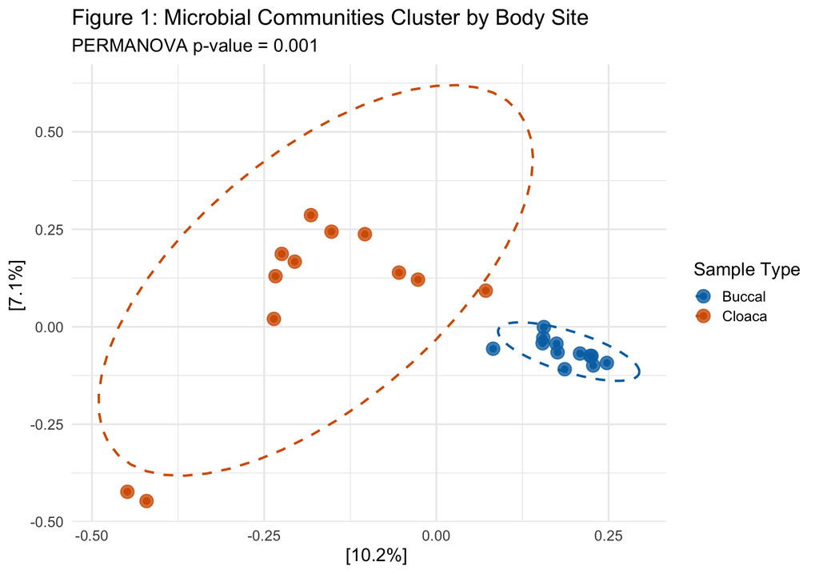

```r
# Create subset without controls
phyloseq_nocontrol <- subset_samples(physeq_final, SampleType != "Control")
phyloseq_nocontrol <- prune_taxa(taxa_sums(phyloseq_nocontrol) > 0, phyloseq_nocontrol)

# Normalize, calculate distance, and perform ordination
physeq_rel_abund <- transform_sample_counts(phyloseq_nocontrol, function(x) x / sum(x))
bray_dist <- phyloseq::distance(physeq_rel_abund, method = "bray")
pcoa_ord <- ordinate(physeq_rel_abund, method = "PCoA", distance = bray_dist)

# Get the PERMANOVA p-value for the subtitle
permanova_test <- adonis2(bray_dist ~ SampleType, data = as(sample_data(physeq_rel_abund), "data.frame"))
p_val <- permanova_test$`Pr(>F)`[1]

# Create the plot
plot_ordination(physeq_rel_abund, pcoa_ord, color = "SampleType") +
  geom_point(size = 5, alpha = 0.8) +
  stat_ellipse(type = "t", linetype = 2, linewidth = 1) +
  scale_color_manual(values = wong_palette) +
  theme_minimal(base_size = 16) +
  labs(
    title = "Figure 1: Microbial Communities Cluster by Body Site",
    subtitle = paste("PERMANOVA p-value =", round(p_val, 3)),
    color = "Sample Type"
  )
```

### Figure 2: The Taxonomic Overview - Phylum Composition

This bar chart gives a high-level view of *who* is in each community. *Note: Since there are many phyla, we use a different, larger color palette for this plot only.*

[figure not shown]

```r
# Aggregate data to the Phylum level and transform to relative abundance
phylum_data <- tax_glom(phyloseq_nocontrol, taxrank = "Phylum", NArm = FALSE)
phylum_rel_abund <- transform_sample_counts(phylum_data, function(x) x / sum(x))
plot_df <- psmelt(phylum_rel_abund)

# Create the plot
ggplot(plot_df, aes(x = Sample, y = Abundance, fill = Phylum)) +
  geom_bar(stat = "identity") +
  facet_wrap(~SampleType, scales = "free_x", nrow = 1) +
  scale_fill_brewer(palette = "Paired") + # Using a larger palette for many phyla
  labs(
    title = "Figure 2: Taxonomic Composition Differs Between Sites",
    x = "Individual Samples", y = "Relative Abundance"
  ) +
  theme_minimal(base_size = 16) +
  theme(
    axis.text.x = element_text(angle = 90, hjust = 1, vjust = 0.5, size = 8),
    strip.text = element_text(face = "bold", size = 16)
  )
```

### Figure 3: The Nuance of Diversity - Alpha Diversity

This box plot shows your important finding that overall diversity was not different, highlighting the nuance of your results.

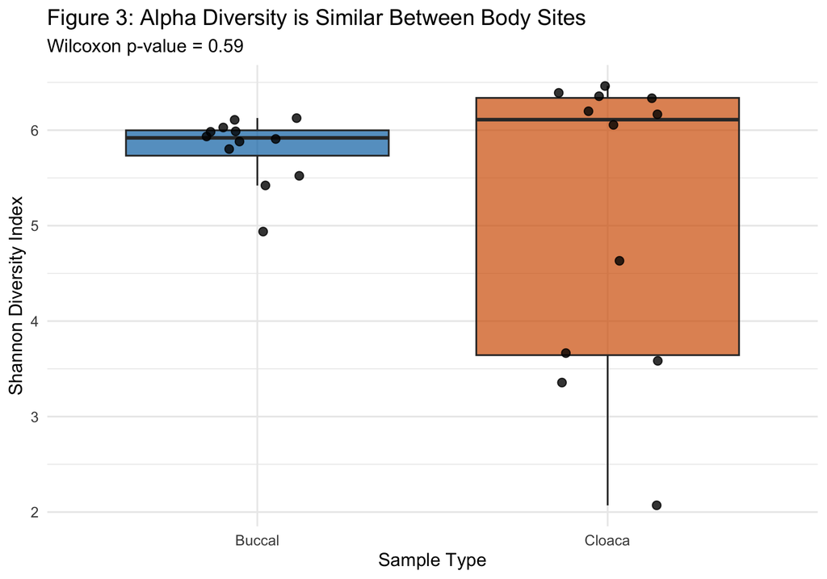

```r
# Calculate and test Shannon diversity
alpha_div <- estimate_richness(phyloseq_nocontrol, measures = "Shannon")
alpha_div$SampleType <- sample_data(phyloseq_nocontrol)$SampleType
stat_test <- wilcox.test(Shannon ~ SampleType, data = alpha_div)

# Create the plot
ggplot(alpha_div, aes(x = SampleType, y = Shannon, fill = SampleType)) +
  geom_boxplot(alpha = 0.7, outlier.shape = NA) +
  geom_jitter(width = 0.15, size = 3, alpha = 0.8) +
  scale_fill_manual(values = wong_palette) +
  theme_minimal(base_size = 16) +
  labs(
    title = "Figure 3: Alpha Diversity is Similar Between Body Sites",
    subtitle = paste("Wilcoxon p-value =", round(stat_test$p.value, 3)),
    x = "Sample Type", y = "Shannon Diversity Index"
  ) +
  theme(legend.position = "none")
```

### Figure 4: The “Smoking Gun” - Pathogen Blooms

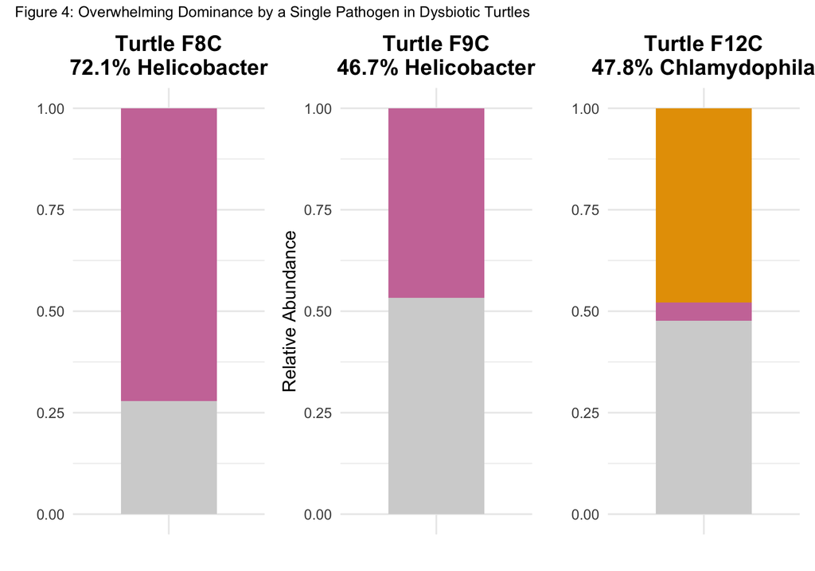

```r
# Define samples and OTUs
samples_of_interest <- c("F8C", "F9C", "F12C")
otu_id_helicobacter <- "Otu000001"
otu_id_chlamydophila <- "Otu000004"

# Process data
physeq_pathogens <- subset_samples(physeq_final, sample_names(physeq_final) %in% samples_of_interest)
physeq_pathogens_rel <- transform_sample_counts(physeq_pathogens, function(x) x / sum(x))
plot_df_path <- psmelt(physeq_pathogens_rel) %>%
  mutate(Taxa_Group = case_when(
    OTU == otu_id_helicobacter ~ "Helicobacter",
    OTU == otu_id_chlamydophila ~ "Chlamydophila",
    TRUE ~ "Other Bacteria"
  ))

# Define colors
pathogen_colors <- c("Helicobacter" = "#CC79A7", "Chlamydophila" = "#E69F00", "Other Bacteria" = "lightgray")

# Plot for F8C
plot_F8C <- ggplot(subset(plot_df_path, Sample == "F8C"), aes(x = Sample, y = Abundance, fill = Taxa_Group)) +
  geom_bar(stat = "identity", width = 0.6) +
  scale_fill_manual(values = pathogen_colors) +
  labs(title = paste0("Turtle F8C\n", round(subset(plot_df_path, Sample == "F8C" & OTU == otu_id_helicobacter)$Abundance*100, 1), "% Helicobacter"), x = "", y = "") +
  theme_minimal(base_size = 16) + theme(legend.position = "none", axis.text.x=element_blank(), plot.title = element_text(hjust = 0.5, face="bold"))

# Plot for F9C
plot_F9C <- ggplot(subset(plot_df_path, Sample == "F9C"), aes(x = Sample, y = Abundance, fill = Taxa_Group)) +
  geom_bar(stat = "identity", width = 0.6) +
  scale_fill_manual(values = pathogen_colors) +
  labs(title = paste0("Turtle F9C\n", round(subset(plot_df_path, Sample == "F9C" & OTU == otu_id_helicobacter)$Abundance*100, 1), "% Helicobacter"), x = "", y = "Relative Abundance") +
  theme_minimal(base_size = 16) + theme(legend.position = "none", axis.text.x=element_blank(), plot.title = element_text(hjust = 0.5, face="bold"))

# Plot for F12C
plot_F12C <- ggplot(subset(plot_df_path, Sample == "F12C"), aes(x = Sample, y = Abundance, fill = Taxa_Group)) +
  geom_bar(stat = "identity", width = 0.6) +
  scale_fill_manual(values = pathogen_colors) +
  labs(title = paste0("Turtle F12C\n", round(subset(plot_df_path, Sample == "F12C" & OTU == otu_id_chlamydophila)$Abundance*100, 1), "% Chlamydophila"), x = "", y = "") +
  theme_minimal(base_size = 16) + theme(legend.position = "none", axis.text.x=element_blank(), plot.title = element_text(hjust = 0.5, face="bold"))

# Arrange plots together (requires the 'patchwork' package)
# install.packages("patchwork")
library(patchwork)
(plot_F8C | plot_F9C | plot_F12C) + plot_annotation(title = "Figure 4: Overwhelming Dominance by a Single Pathogen in Dysbiotic Turtles")
```

### Figure 5: The Grand Summary - All Findings in One Plot

This is the final, definitive PCoA plot that highlights all your case studies and tells the complete story on a single slide.

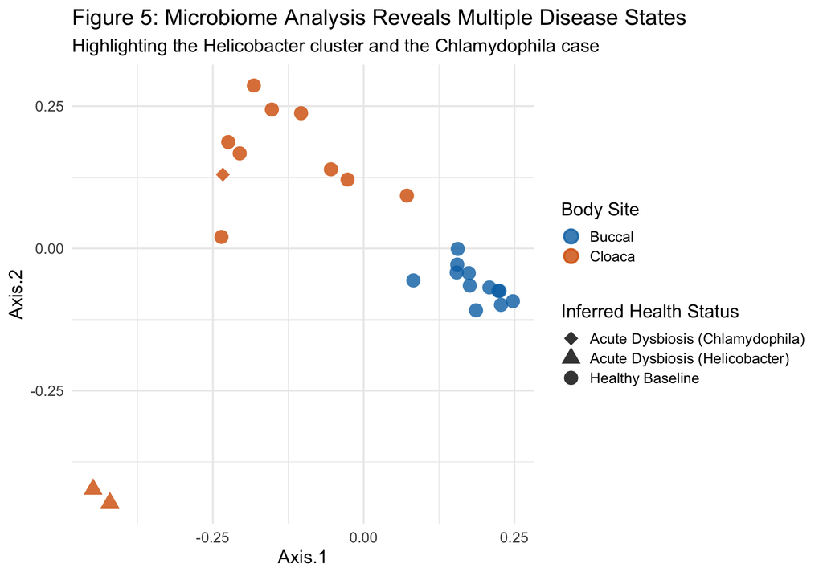

```r
# Define samples of interest
helicobacter_cluster <- c("F8C", "F9C")
chlamydia_case <- "F12C"

# Prepare data for plotting
plot_data <- data.frame(pcoa_ord$vectors[, 1:2], as(sample_data(phyloseq_nocontrol), "data.frame")) %>%
  mutate(Health_Status = case_when(
    rownames(.) %in% helicobacter_cluster ~ "Acute Dysbiosis (Helicobacter)",
    rownames(.) == chlamydia_case         ~ "Acute Dysbiosis (Chlamydophila)",
    TRUE                                 ~ "Healthy Baseline"
  ))

# Build the plot
ggplot(plot_data, aes(x = Axis.1, y = Axis.2)) +
  geom_point(aes(color = SampleType, shape = Health_Status), size = 5, alpha = 0.8, stroke = 1.2) +
  scale_color_manual(values = wong_palette) +
  scale_shape_manual(values = c("Healthy Baseline" = 16, "Acute Dysbiosis (Helicobacter)" = 17, "Acute Dysbiosis (Chlamydophila)" = 18)) +
  theme_minimal(base_size = 16) +
  labs(
    title = "Figure 5: Microbiome Analysis Reveals Multiple Disease States",
    subtitle = "Highlighting the Helicobacter cluster and the Chlamydophila case",
    color = "Body Site", shape = "Inferred Health Status"
  )
```